# Spatial Data Science with R. Day 2.

## Geostatistics

Geostatistics is concerned with *field* variables, i.e. variables that

- vary continuously over space, or space/time
- can meaningfully be *interpolated* (predicted) at unobserved locations

That is, *not* with marked point patterns, such as

- tree stem diameters
- coal power plant emissions

although both share the property of being "xyz" data (point coordinates + attributes)

## Overview

- spatial correlation: (semi)variogram, auto-covariogram, auto-correllogram
- spatial prediction:
  - when is spatial prediction meaningful? fields and point processes.
  - stationarity, ergodicity
  - prediction errors
  - change of support
- exporartory data analysis: distance distributions, the h-scatterplot
- computing and modelling variograms
- kriging prediction
- regression models with stationary residuals
- multivariable geostatistics: co-kriging
- modelling non-stationary processes: transformation, stratification
- spatiotemporal geostatistics
- machine learning approaches to spatial prediction

## spatial prediction:

Given \(n\) observations \(z(x_1), ...,z(x_n)\) we assume a model, \(Z(x) = Z(x_1),...,Z(x_n)\) where \(Z\) is random, and \(x\) is not.

Spatial prediction (Kriging) is concerned with predicting unobserved values \(Z(x_0)\), by using a linear predictor \[\hat{Z}(x_0) = \sum_{i=1}^n \lambda_i Z(x_i)\] where weights are chosen such that \(E(\hat{Z}(x_0)) = E(Z(x_0))\) and \(Var(\hat{Z}(x_0)-Z(x_0))\) is minimal.

This is meaningful for point patterns only if there is a missing value, i.e. if \(x_0\) has a tree for which we don't know the tree diameter. For field variables, such as air temperature, we have missing values pretty much *everywhere*, and thus can estimate \(Z(x)\) over a continuous *surface*.

## Stationarity, ergodicity

For finding the Kriging weights, we need to know all (co)variances of and between the \(Z(x_i)\) and \(Z(x_0)\). This can only be done by making stationarity assumptions. E.g. second order stationarity involves

- stationarity of the mean: \(E(Z(x)) = m\)
- stationarity of the variance: \(E(Z(x)-m)^2 = C(0)\)
- stationarity of the covariance: \(E(((Z(x)-m)(Z(x+h)-m))) = C(h)\)

or the slightly weaker intrinsic stationarity works on increments:

- mean: \(E(Z(x)-Z(x+h)) = 0\)
- variance: \(E(Z(x)-Z(x+h))^2 = 2 \gamma(h)\)

\(C(h)\) is called the covariogram, \(\gamma(h)\) is called the semivariogram, or variogram.

For second order stationary fields, i.e. \(C(0) < \infty\), we have \[C(0) - C(h) = \gamma(h)\] and the *correlogram* defined as \(C(h)/C(0)\).

**Ergodicity** involves the esimation of \(\gamma(h)\), or \(C(h)\), from a single sample of the random field \(Z\). It (very) roughly means that the data must contain the information sought. This is not the case when

- Using temperature data from Munich to estimate \(\gamma(h)\) for distances larger than a few kilometers, as would be needed for interpolating temperatures over Germany
- there is no repetition or regularity, but e.g. composition of different processes with very different properties in the data set

## Estimating spatial correlation

Spatial correlation is estimated from sample data, by

- forming (all \(n(n-1)/2\)) pairs \(Z(x_i), Z(x_j)\)
- computing distances \(h=|x_i-x_j|\)
- grouping the pairs by distance class
- for each distance class, compute (half) the average of \((Z(x_i)-Z(x_j))^2\)
- this gives estimates of \(\gamma(h)\) for a set of distance values
- to this sample variogram, a parametric model is fitted
- alternative: use maximum likelihood
  - assumes multivariate Gaussian distribution
  - involves iteratively solving systems of size \(n\)

## explorartory data analysis: distance distributions, the h-scatterplot

We will explore an air quality dataset collected from the EEA's airbase (as of, "air quality database"), prepared in the gstat package:

```r
data(DE_RB_2005, package = "gstat")
library(spacetime)
library(stars)
s = st_as_stars(as(DE_RB_2005, "STFDF"))
# select a single day, omit NA values:
s1 = na.omit(st_as_sf(s[,,100]))
names(s1)[1] = "PM10"
```

```r
library(gstat)
variogram(PM10~1, s1)
```

```
##     np      dist     gamma dir.hor dir.ver   id
## 1    4  18898.55  7.020488       0       0 var1
## 2   23  34364.92  6.440393       0       0 var1
## 3   32  56345.09 11.255562       0       0 var1
## 4   39  77732.46  7.906209       0       0 var1
## 5   55  99506.37  8.341365       0       0 var1
## 6   71 122440.26  9.902675       0       0 var1
## 7   85 143636.56 15.158993       0       0 var1
## 8   80 164572.07 13.839935       0       0 var1
## 9   91 187694.48 12.821504       0       0 var1
## 10  88 209843.86 14.708895       0       0 var1
## 11  98 231000.08 17.078920       0       0 var1
## 12 110 254882.02 22.609394       0       0 var1
## 13 104 276259.20 22.452120       0       0 var1
## 14 101 297576.88 18.176579       0       0 var1
## 15  91 320326.70 28.031442       0       0 var1
```

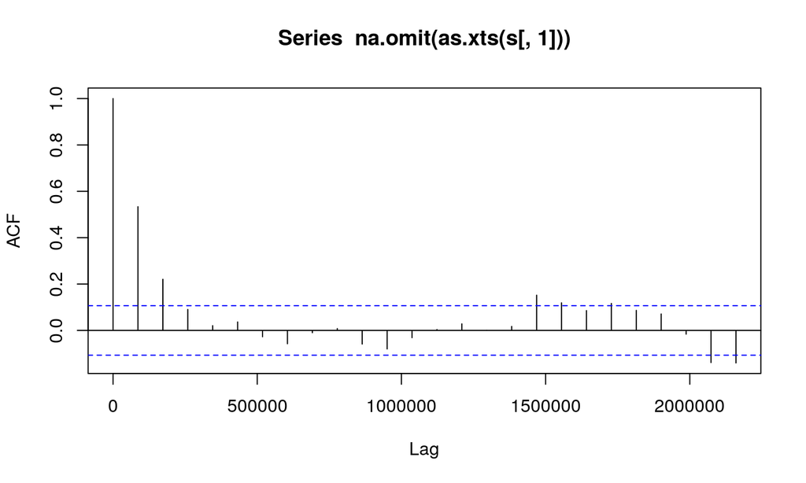

```r
suppressPackageStartupMessages(library(xts))
acf(na.omit(as.xts(s[,1])))
```

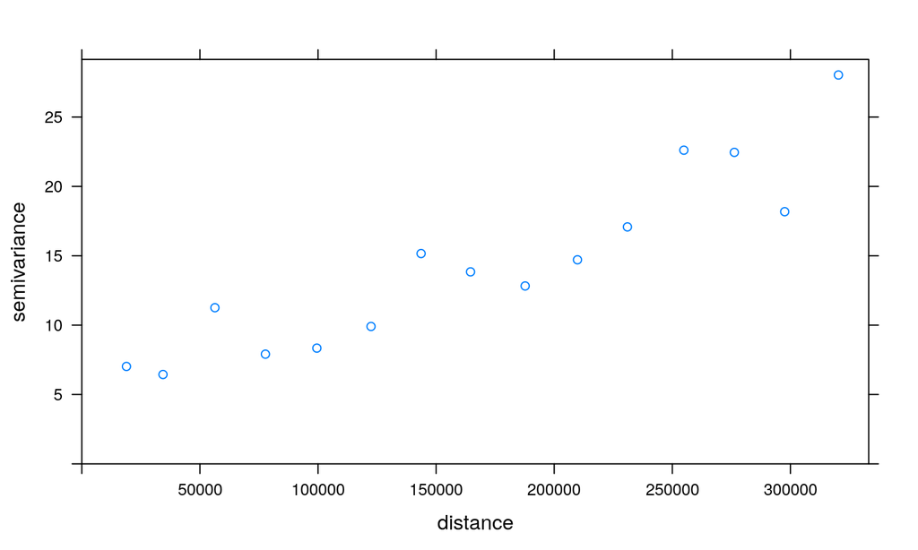

```r
plot(variogram(PM10~1, s1))
```

## Exercises 3: variograms

Building on the above dataset, create out plot where:

- setting the `cutoff` to a much larger, and a much smaller value
- setting the `width` argument to a larger and smaller value
- the number of point pairs involved is also shown in the plot
- setting `cloud=TRUE` - what do the points in this plot represent? (hint: plot the number of point pairs)
- Save a variogram you like to an object, and fit a model to it using `fit.variogram`; use `vgm()` to list the possible models and `show.vgms()` to get an idea how they look.
- If you get errors on fit, don't worry:
  - plot the variogram with fitted model (like: `plot(v, fit)`, and examine how it looks
  - try to choose better initial values for nugget (offset), sill (final level), range (distance where correlation no longer increases)

## kriging prediction

Settle on some variogram; we choose:

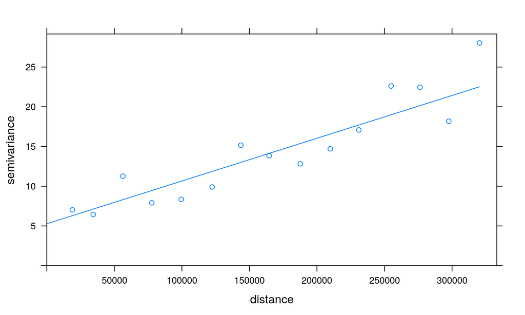

```r
v = variogram(PM10~1, s1)
f = fit.variogram(v, vgm(20, "Lin", 0, 4))
plot(v, f)
```

Create a grid, using stars:

```r
# load German boundaries
data(air, package = "spacetime")
de <- st_transform(st_as_sf(DE_NUTS1), 32632)
bb = st_bbox(de)
dx = seq(bb[1], bb[3], 10000)
dy = seq(bb[4], bb[2], -10000) # decreases!
st_as_stars(matrix(0., length(dx), length(dy))) %>%
  st_set_dimensions(1, dx) %>%
  st_set_dimensions(2, dy) %>%
  st_set_crs(32632) -> grd
```

## Inverse distance interpolation

```r
i = idw(PM10~1, s1, grd)
```

```
## [inverse distance weighted interpolation]
```

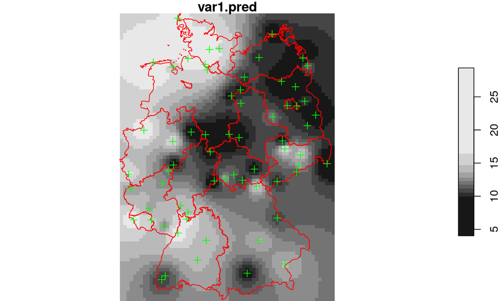

```r
plot(i, reset = FALSE, key.pos = 4) # allow addition
plot(st_geometry(de), add = TRUE, border = 'red')
plot(s1, add = TRUE, col = 'green', pch = 3)
```

## Kriging

```r
kr = krige(PM10~1, s1, grd, f)
```

```
## [using ordinary kriging]
```

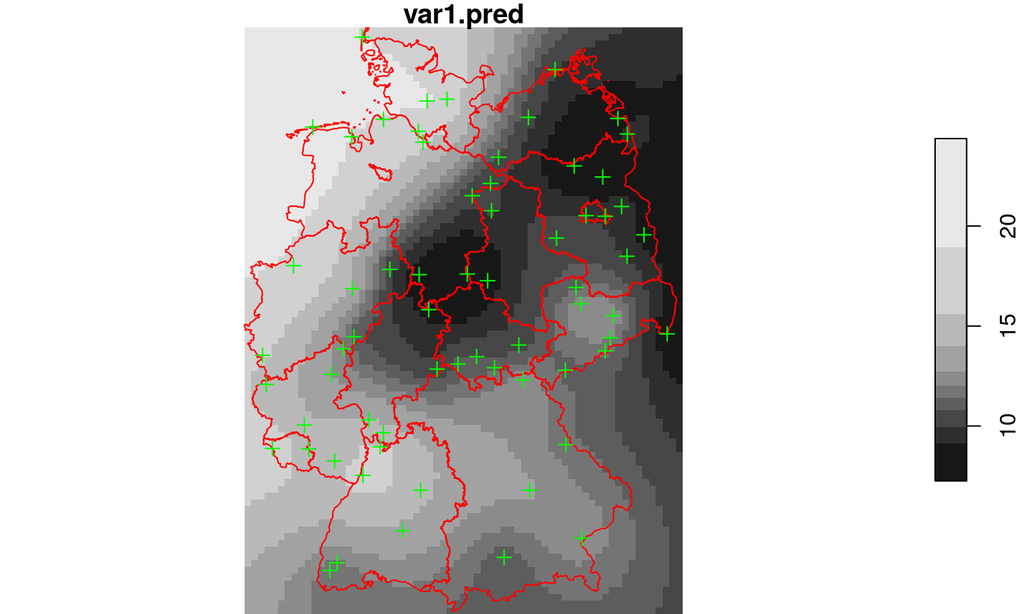

```r
plot(kr, reset = FALSE, key.pos = 4) # allow addition
plot(st_geometry(de), add = TRUE, border = 'red')
plot(s1, add = TRUE, col = 'green', pch = 3)
```

## Comparing maps (!)

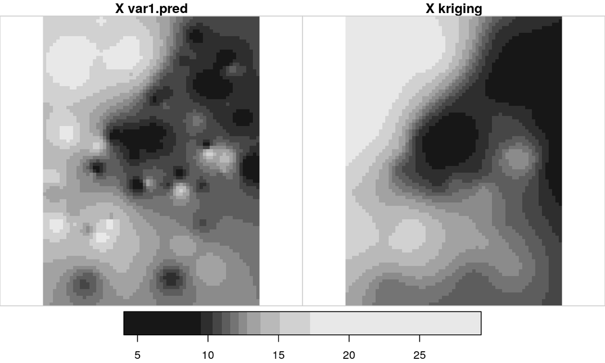

```r
i[[2]] = NULL # remove this attribute
i$kriging = kr[[1]] # add attribute named "kriging" to i
plot(merge(i))
```

## Exercises (4)

- Compare the ranges of the kriging and idw map, and the range of the PM10 data. Explain differences and correspondences.
- Examine the kriging variance error map.
- Compute a standard error map by taking the square root of the kriging variance
- Plot this map with the data points overlayed: can you explain the pattern in the errors?
- Repeat the exercise with the same linear model but with a zero nugget effect, and compare the ranges again.
- Repeat the exercise with the a spherical model with a short range and zero nugget, and compare the ranges again.
- Repeat the exercise with the a pure nugget effect model (e.g., `vgm(20, "Nug", 0)`), and compare the ranges again.
- Compute (approximate) 95% prediction intervals by adding +/- 2 standard errors to the kriging
- Create a map with locations where the threshold of 25 has been exceeded, or might have been exceeded (is inside the prediction interval)

## prediction errors

Given the kriging predictor, we also obtain a kriging error \[\sigma(x_0) = E((\hat{Z}(x_0)-Z(x_0))^2)\] which

- is an *average* measure of error, given that all assumptions are met
- only depends on (co)variances, and not on data values (i.e., is only configuration dependent)
- will be Normally distributed if \(Z(s)\) is multivariate Gaussian
- (ordinary, universal) kriging involves the assumption that the mean process (\(m\)) is unknown, but \(\gamma(h)\) is known

## Change of support

Change of support involves estimating block averages of the form \[\frac{1}{|A|}\int_A Z(u)du\]

or other aggregations of the form \[\frac{1}{|A|}\int_A g(Z(u))du\] which could, for instance, estimate the fraction of an area for which a certain threshold is exceeded, if \(g(\cdot)\) is an indicator function.

## Change of support (2)

The integrals are usually approximated by a weighted or unweighted sum; the linear average is obtained by *block kriging*, the non-linear by

1. *stochastic* simulation of \(Z\) at the point support,
2. then applying \(g()\),
3. then spatially aggregating

## Exercises (5)

- Carry out a block kriging, setting `block=c(10000,10000)` to estimate 10 km x 10 km block mean values
- Compare the kriged values to those obtained by point kriging, compare the ranges
- Compare the standard errors between point and block kriging

## regression models with stationary residuals

- Universal kriging (syn. regression kriging, or external drift kriging) extends the model with a constant mean to that where \(E(Z(x)) = F(x)\beta\), i.e. a multiple linear regression model with known, spatially varying covariates \(F(x)\)
- The spatial prediction now becomes a combination of estimated trend + predicted residual, leaning on the trend surface when data are remote or weakly correlated

## multivariable geostatistics: co-kriging

- Co-kriging considers multiple variable *at once*
- It requires, besides direct variograms, the cross variograms describing cross correlations for *pairs* of variables
- It mostly helps (improves prediction) when a secondary variable has higher sampling rate
- It is needed when we need the estimation error of some composite index, e.g. the sum or difference of a set of variables

## modelling non-stationary processes: transformation, stratification

- Common transformations: Box-Cox, logarithmic
- Broader group of models: generalized linear mixed models (exponential family); calls for MCMC or INLA
- Stratification: cut up the area in peaces, model + interpolate for each zone; this gives sudden boundaries at zone boundaries

## spatiotemporal geostatistics

- Can be seen as an extension of co-kriging, but continuous covariance model over space *and* time is needed
- Modelling cumbersome, but doable, see https://journal.r-project.org/archive/2016/RJ-2016-014/index.html for a reproducible example
- Needed if a continuous spatiotemporal surface is needed; kriging per time slice gives sudden jumps, in particular if variograms are re-estimated and changes are not smoothed over time.

## machine learning approaches to spatial prediction

- Difficulty: assumption of independent observations.
- Needed: strategies for calibration/validation - don't do random, but take out space/time blocks
- If two observations are close in space, they will have similar features; does the feature similarity yield better predictions, or the spatial correlation?

## Stochastic simulation

```r
f = vgm(20, "Sph", 200000, 5)
sim = krige(PM10~1, s1, grd, f, nsim = 100, nmax = 30)
```

```
## drawing 100 GLS realisations of beta...
## [using conditional Gaussian simulation]
```

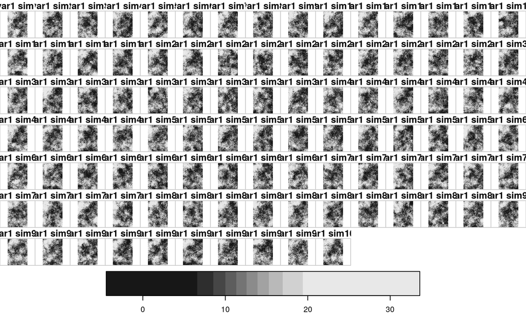

```r
plot(sim)
```

## Compare mean of simulations with kriged value

```r
kr = krige(PM10~1, s1, grd, f)
```

```
## [using ordinary kriging]
```

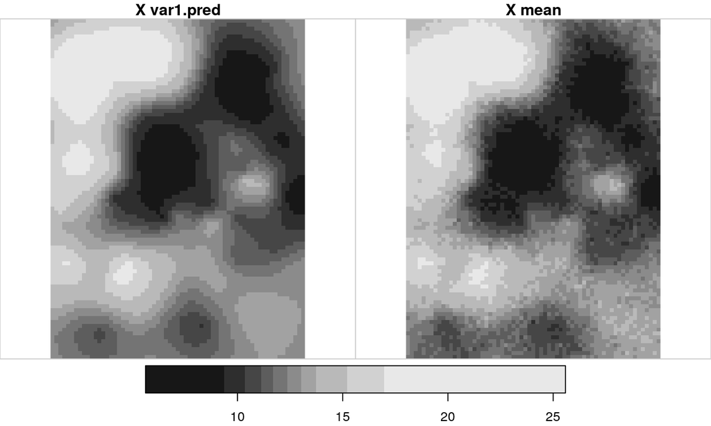

```r
kr$mean = st_apply(sim, 1:2, mean)[[1]]
dim(kr[[3]]) = dim(kr[[1]]) # Ooops!
plot(merge(kr[c(1,3)]))
```

## Variogram of simulations

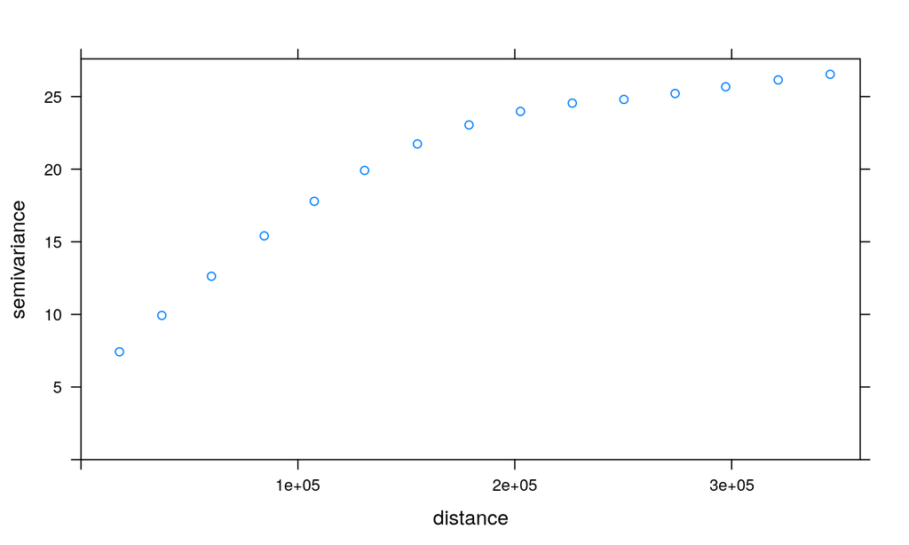

```r
plot(variogram(V1~1, st_as_sf(sim[,,,1])))
```

## Variogram of kriging values

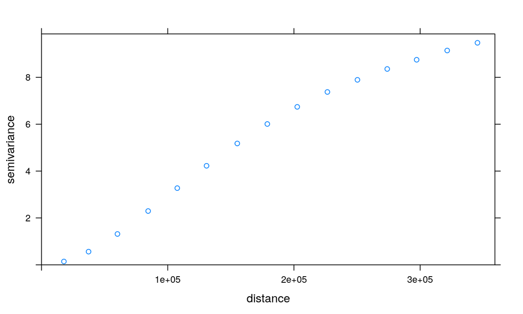

```r
plot(variogram(var1.pred~1, st_as_sf(kr[1])))
```

## Spatial aggregation

Aggregate the fraction of cells where PM10 exceeds 25

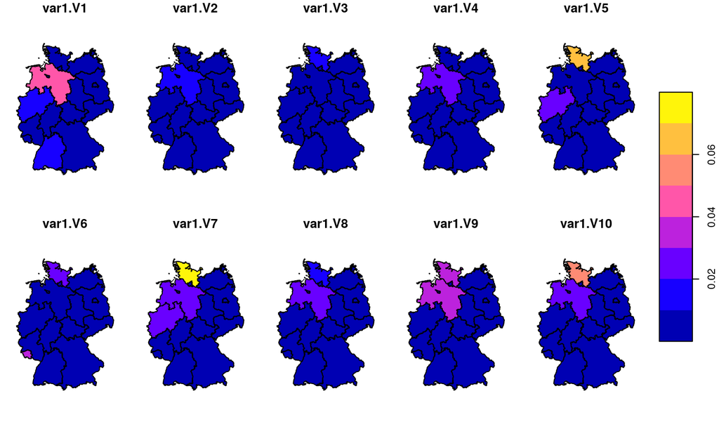

```r
a = aggregate(sim, de, function(x) mean(x > 25))
plot(a, max.plot = 10, key.pos = 4)
```

## Summarizing the simulations

Compute 95% confidence limits:

```r
a.ci = st_apply(a, 1, quantile, c(0.025, 0.975))
a.ci
```

```
## stars object with 2 dimensions and 1 attribute
## attribute(s):
##      var1
##  Min.   :0.00000
##  1st Qu.:0.00000
##  Median :0.00000
##  Mean   :0.01008
##  3rd Qu.:0.00000
##  Max.   :0.16074
## dimension(s):
##          from to offset delta                       refsys point
## quantile    1  2     NA    NA                           NA    NA
## geometry    1 16     NA    NA +proj=utm +zone=32 +datum... FALSE
##                                                                     values
## quantile                                                      2.5% , 97.5%
## geometry MULTIPOLYGON (((546832.3 55...,...,MULTIPOLYGON (((622596.9 57...
```

C.I. for the *areal fraction* of *point* values over a state where PM10 > 25 (non-linear spatial aggregation)

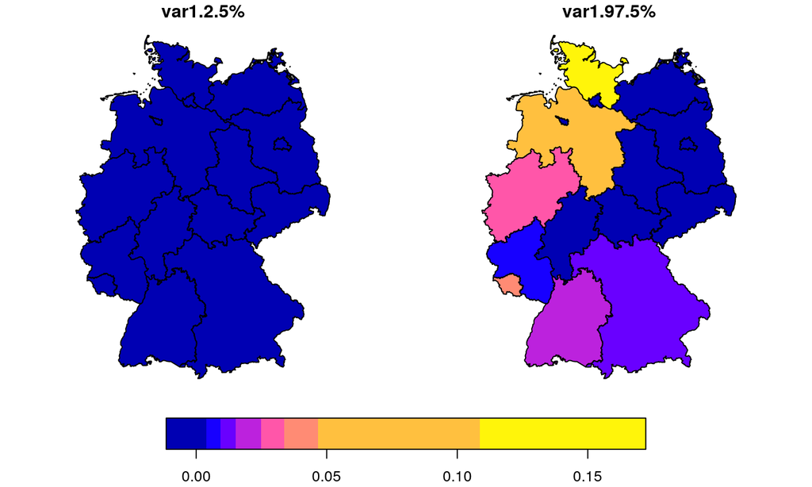

```r
plot(aperm(a.ci, 2:1))
```